# Thesis Preliminary Analysis

Alice Tivarovsky

1/13/2020

## Data Import and Tidying

Reading in cycles 2015-2016 and 2013-2014, datasets: demographics (DEMO), diet behavior and nutrition (DBQ), Phthalates and Plasticizers Metabolites - Urine (PHTHTE), Personal Care and Consumer Product Chemicals and Metabolites (EPHPP) in the 2015-2016 and 2013-2014 cycles, and Environmental Phenols & Parabens (EPH_G) 2011-2012 cycles.

Merging everything into one dataframe:

Select variables of interest:

We start with 20,146 observations before any exclusion criteria are applied.

Restrict to women 18 - 44 with biomarker data.

```
## [1] 18
```

Next, we recode the education variables because education for 18-20 year olds is coded differently from those > 20 years old. First we get the range to understand the scope of recode.

```
## [1] 1 9
```

Now, we recode marital status for 18 and 19-year olds, who were not asked the question. NA’s are replaced with 5 (Never Married).

We note that we have 2 income variables, annual household income (INDHHIN2) and annual family income (INDFMIN2). They have the same coding structure, and are likely highly correlated. We will remove one of them for further analysis, but first we confirm the correlation. Running the correlation below, r = 0.9720947, confirming correlation. We proceed with only family income.

```
##           INDHHIN2  INDFMIN2
## INDHHIN2 1.0000000 0.9720947
## INDFMIN2 0.9720947 1.0000000
```

Finally, we clean up the variable names and types and remove NA vectors (URXHIBP, URXMCOH, URXMHBP). We omit household income, per the correlation above, and the first ethnicity variable (ridreth1), which is less information than ridreth3.

## Exploratory data analysis

### Distributions

Independent variable histograms:

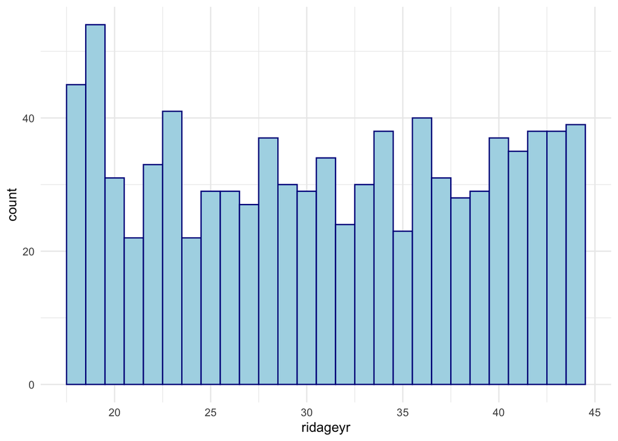

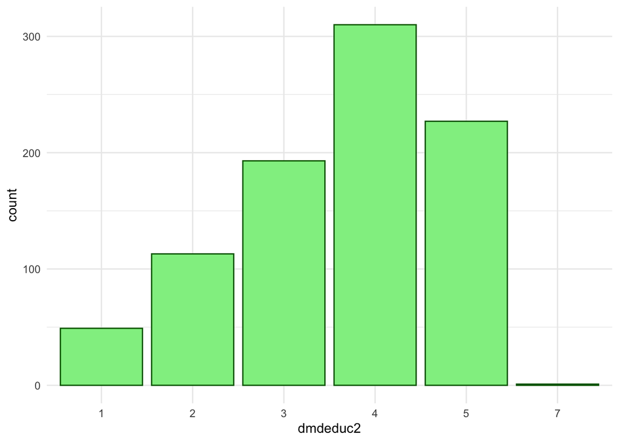

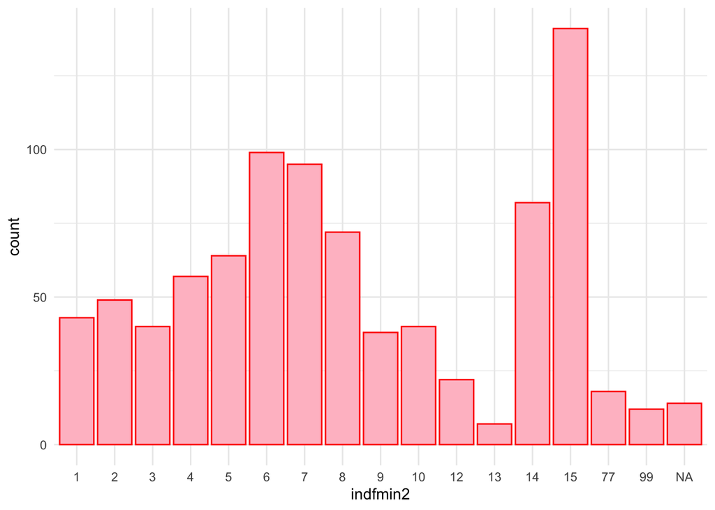

Outcome variable histograms (to understand if log adjustment is necessary). First we look at phenols. The three phenol distributions indicate right-skewed data, suggesting the need to log-transform.

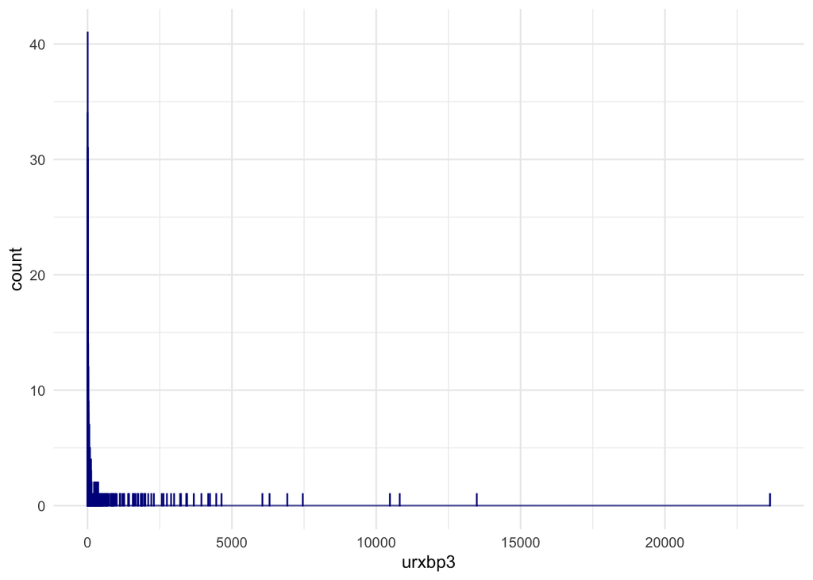

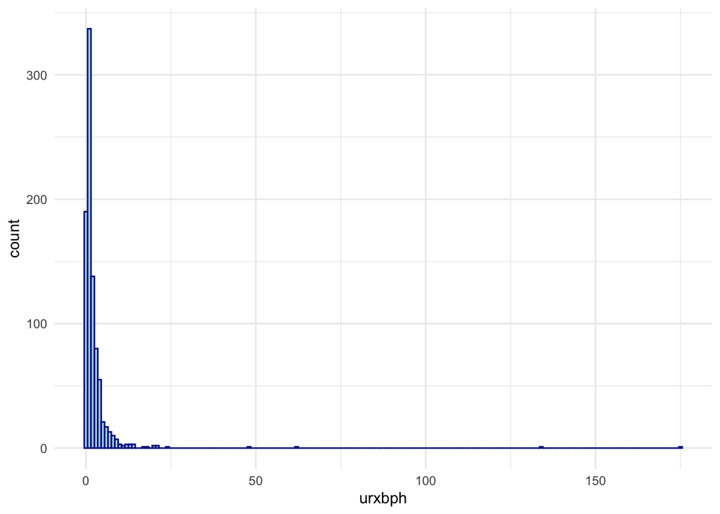

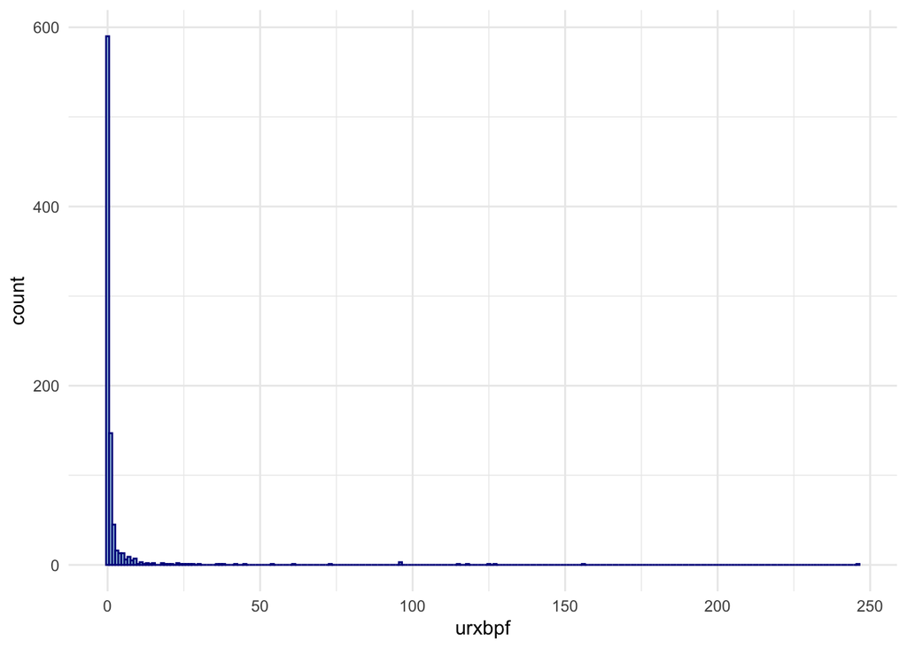

Next we examine the phthalate distributions. Similarly, the phthalates are right-skewed.

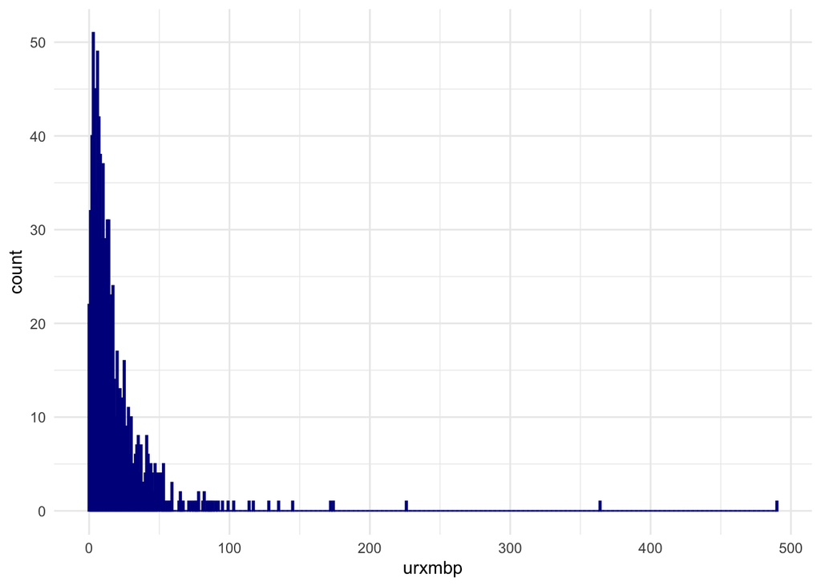

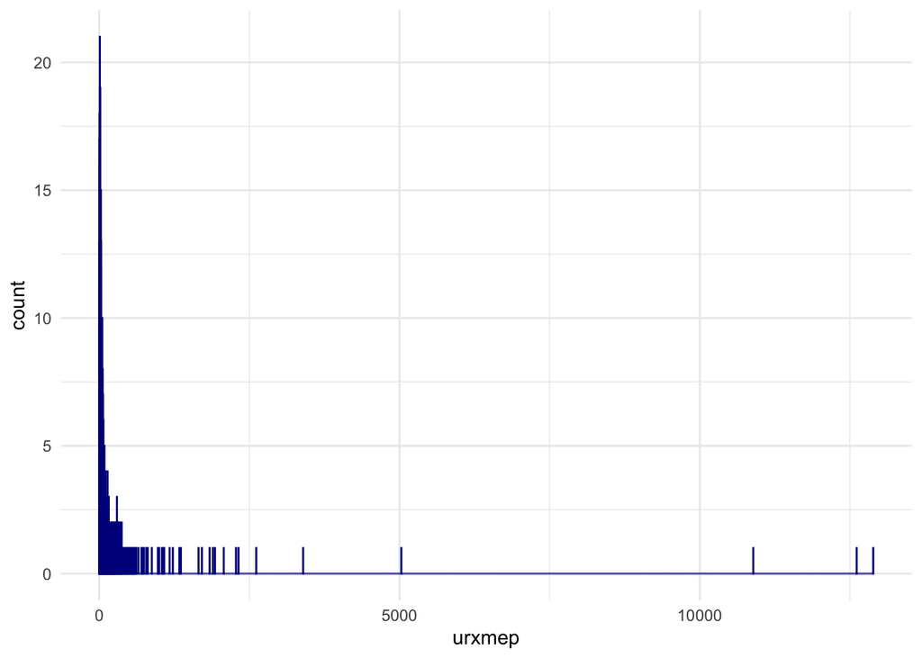

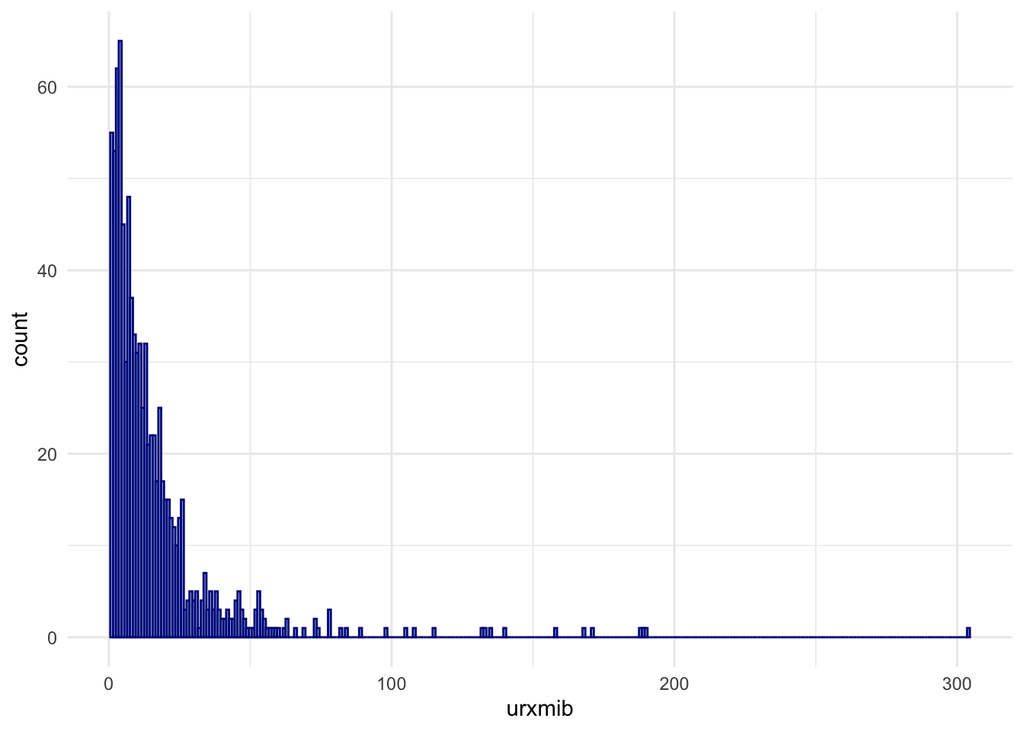

### Table 1

```
##
##                                                         Overall
##   n                                                       893
##   Age (mean (SD))                                       30.96 (8.18)
##   Ethnicity (%)
##      Mexican American                                     146 (16.3)
##      Other Hispanic                                        96 (10.8)
##      Non-Hispanic White                                   278 (31.1)
##      Non-Hispanic Black                                   217 (24.3)
##      Non-Hispanic Asian                                   122 (13.7)
##      Other Race - Including Multi-Racial                   34 ( 3.8)
##   Education (%)
##      Less than 9th grade                                   49 ( 5.5)
##      9-11th grade (Includes 12th grade with no diploma)   113 (12.7)
##      High school graduate/GED or equivalent               193 (21.6)
##      Some college or AA degree                            310 (34.7)
##      College graduate or above                            227 (25.4)
##      Refused                                                1 ( 0.1)
##   MaritalStatus (%)
##      Divorced                                              59 ( 6.6)
##      Living with partner                                  107 (12.0)
##      Married                                              349 (39.1)
##      Never married                                        338 (37.8)
##      Separated                                             33 ( 3.7)
##      Widowed                                                7 ( 0.8)
##   FamilyIncome (%)
##      $ 0 to $ 4,999                                        43 ( 4.9)
##      $ 5,000 to $ 9,999                                    49 ( 5.6)
##      $10,000 to $14,999                                    40 ( 4.6)
##      $15,000 to $19,999                                    57 ( 6.5)
##      $20,000 to $24,999                                    64 ( 7.3)
##      $25,000 to $34,999                                    99 (11.3)
##      $35,000 to $44,999                                    95 (10.8)
##      $45,000 to $54,999                                    72 ( 8.2)
##      $55,000 to $64,999                                    38 ( 4.3)
##      $65,000 to $74,999                                    40 ( 4.6)
##      $20,000 and Over                                      22 ( 2.5)
##      Under $20,000                                          7 ( 0.8)
##      $75,000 to $99,999                                    82 ( 9.3)
##      $100,000 and Over                                    141 (16.0)
##      77                                                    18 ( 2.0)
##      99                                                    12 ( 1.4)
```

## Modeling

Due to the complex sampling structure of NHANES, we need to account for survey weights. We use the survey package and subset our desired population (women aged 18 - 44). First we perform the same tidying steps we used for the exploratory analysis. We note that we cannot use the same dataset used in the exploratory analysis because application of the survey weights requires that we retain all observations and restrict the data using subsetting rather than filtering.

```
##            mean     SE
## ridageyr 31.105 0.2253
```

```
##
## Call:
## svyglm(formula = log(urxbp3) ~ ridageyr + factor(ridreth3) +
##     factor(dmdeduc2) + factor(dmdmartl) + factor(indfmin2), design = ageDesign,
##     family = gaussian(), data = model_data)
##
## Survey design:
## subset(nhanesDesign, riagendr == 2 & ridageyr > 17 & ridageyr <
##     45 & !indfmin2 %in% c(77, 99))
##
## Coefficients:
##                     Estimate Std. Error t value Pr(>|t|)
## (Intercept)         3.227611   0.903790   3.571   0.0702 .
## ridageyr           -0.021707   0.014079  -1.542   0.2631
## factor(ridreth3)2   0.463354   0.321888   1.439   0.2867
## factor(ridreth3)3   0.498404   0.257819   1.933   0.1929
## factor(ridreth3)4  -0.391638   0.286428  -1.367   0.3049
## factor(ridreth3)6   0.126419   0.288039   0.439   0.7036
## factor(ridreth3)7   1.031337   0.564647   1.827   0.2093
## factor(dmdeduc2)2  -0.453509   0.412534  -1.099   0.3863
## factor(dmdeduc2)3  -0.574986   0.415348  -1.384   0.3005
## factor(dmdeduc2)4  -0.139174   0.423499  -0.329   0.7737
## factor(dmdeduc2)5   0.389155   0.402834   0.966   0.4359
## factor(dmdmartl)2  -0.019731   0.569683  -0.035   0.9755
## factor(dmdmartl)3   0.412186   0.484260   0.851   0.4843
## factor(dmdmartl)4   0.064365   0.320524   0.201   0.8594
## factor(dmdmartl)5   0.007286   0.261233   0.028   0.9803
## factor(dmdmartl)6   0.223669   0.390383   0.573   0.6245
## factor(indfmin2)2  -0.213958   0.624209  -0.343   0.7644
## factor(indfmin2)3   0.405850   0.570685   0.711   0.5507
## factor(indfmin2)4   0.494425   0.475825   1.039   0.4079
## factor(indfmin2)5   0.933056   0.531764   1.755   0.2214
## factor(indfmin2)6   0.542603   0.513605   1.056   0.4015
## factor(indfmin2)7   0.936234   0.522711   1.791   0.2152
## factor(indfmin2)8   0.773580   0.467335   1.655   0.2397
## factor(indfmin2)9   0.947248   0.604920   1.566   0.2579
## factor(indfmin2)10  0.343299   0.586049   0.586   0.6173
## factor(indfmin2)12  0.340297   0.539952   0.630   0.5929
## factor(indfmin2)13  2.825792   1.042080   2.712   0.1133
## factor(indfmin2)14  0.632846   0.541436   1.169   0.3629
## factor(indfmin2)15  1.266992   0.499951   2.534   0.1268
## ---
## Signif. codes:  0 '***' 0.001 '**' 0.01 '*' 0.05 '.' 0.1 ' ' 1
##
## (Dispersion parameter for gaussian family taken to be 4.128265)
##
## Number of Fisher Scoring iterations: 2
```

## Trying unweighted

```
## # A tibble: 1 x 11
##   r.squared adj.r.squared sigma statistic  p.value    df logLik   AIC   BIC
##       <dbl>         <dbl> <dbl>     <dbl>    <dbl> <int>  <dbl> <dbl> <dbl>
## 1     0.116        0.0858  1.96      3.84 1.84e-10    29 -1760. 3579. 3721.
## # … with 2 more variables: deviance <dbl>, df.residual <int>
```